# Intro to R for Data Analysis

An introduction to R for data analysis for NYU Wagner class (URPL-GP-1620) in Fall 2021

Maxwell Austensen https://github.com/austensen  
2021-10-18

### Table of Contents

All the demo materials are available on [GitHub](https://github.com/urpl-gp-1620-2021/r-class-1).

# R

[R](https://www.r-project.org/) is a free and open-source software environment for statistical computing and graphics. It has a more narrow set of uses and a smaller user base compared python, but because it is specifically designed for data analysis it is a great language for data analysts to learn. In recent years it has become increasingly popular and has also become much easier to learn, especially for those new to coding.

There are three main reasons that I enjoying using R myself and teaching it to others.

1. R has an amazing community of users that have produced wealth of user friendly guides, documentation, and other tools and resources to support people learning the language.
2. [RStudio](https://www.rstudio.com/products/rstudio/) is an incredibly helpful application (Integrated Development Environment) in which you can work with R.
3. A wide ecosystem of user-written packages that provide tools for almost every possible use case. Especially important is the collection of packages known as the *Tidyverse* that prioritize good design and documentation that make it easy to learn R.

## R Community Resources

Here is just a small sample of some of the great resources available for learning R:

- [R for Data Science](http://r4ds.had.co.nz/), a wonderful free book that provides a good introduction to R for data analysis
- [Tidyverse packages website](http://Tidyverse.org) provides comprehensive documentation for all packages, including helpful guides and examples
- [Stat545](http://stat545.com/index.html), a university course on data science with R that shares most of the materials
- RStudio [webinars](https://www.rstudio.com/resources/webinars/), [online learning materials](https://www.rstudio.com/online-learning/), and [cheatsheets](https://www.rstudio.com/resources/cheatsheets/)
- [RStudio Community](https://community.rstudio.com/), a friendlier version of StackOverflow dedicated to R and RStudio packages
- [StackOverflow for R](https://stackoverflow.com/questions/tagged/r)

## RStudio

The [RStudio Desktop](https://www.rstudio.com/products/rstudio/#Desktop) application is free to download.

They also now provide [Rstudio Cloud](https://rstudio.cloud) as a free service that works just like RStudio Desktop but it is all accessed through the browser and requires no installation. There are some limitations on the number of hours you can use it, so for this course we’ll be working with the desktop version.

This is the default RStudio interface.

- The top left pane contains all your code files. This is where you can write and save all the code for your analysis.
- The bottom left pane has the R console where you can run individual pieces of R code, such as quick calculations, printing objects, or anything else that you don’t need to save in your final files.
- The top right pane contains a list of all the objects currently in your environment. If you click on a dataframe object it will open in a viewer in the top left pane where you can browse, sort, and filter your view of the data (without altering the object itself)
- The bottom right pane contains a few important tabs: the plot viewer where any graphs you create will appear, the files explorer, and the help page

[figure not shown]

## Packages in R

### Installing and Loading Packages

R is an open-source language so in addition to the basic functions that come standard with R (referred to as *Base R*) there are more than 10,000 user written packages that can accomplish virtually any task in R. There is an official repository for these packages called CRAN that does some vetting of the quality of packages, and packages from here can be installed directly from R using:

```r
install.packages("PackageName")
```

These packages only need to be installed like this once, and after that initial installation we only need to load the packages that we want use for each analysis with `library()`.

All of the packages we are using here are part of a collection of R packages referred to as the [`tidyverse`](https://www.tidyverse.org/).

> The Tidyverse is an opinionated collection of R packages designed for data science. All packages share an underlying design philosophy, grammar, and data structures. All of these packages are extremely well-maintained and have helpful websites that include, examples and guides, function documentation, cheatsheets, and links to the GitHub repos where the packages are developed. The following are the core set of Tidyverse packages, but there are [many more](https://www.tidyverse.org/packages/).
- [`dplyr`](https://dplyr.Tidyverse.org) is a grammar of data manipulation, providing a consistent set of verbs that help you solve the most common data manipulation challenges
- [`readr`](https://readr.Tidyverse.org) provides a fast and friendly way to read rectangular data (like csv, tsv, and fwf)
- [`tidyr`](https://tidyr.Tidyverse.org) helps you create tidy data. Tidy data is data where: Each variable is in a column, each observation is a row, and each value is a cell
- [`stringr`](https://stringr.Tidyverse.org) provides a cohesive set of functions designed to make working with strings as easy as possible
- [`forcats`](https://forcats.Tidyverse.org) provides a suite of useful tools that solve common problems with factors
- [`purrr`](https://purrr.Tidyverse.org) is a complete and consistent set of tools for working with functions and vectors
- [`ggplot2`](https://ggplot2.Tidyverse.org) is a system for declaratively creating graphics, based on The Grammar of Graphics

In addition to the package websites, there is an amazing free book that covers how to use all these packages to do data analysis, called [*R for Data Science*](http://r4ds.had.co.nz/).

There is a special `tidyverse` package that installs all the related package, and using `library(tidyverse)` loads all seven of these core packages.

```r
library(dplyr) # manipulate dataframes
library(readr) # read/write dataframes
library(tidyr) # reshaping dataframes
library(stringr) # string manipulation
library(forcats) # factor manipulation
library(purrr) # iteration (instead of loops)
library(ggplot2) # making plots
```

# Import and Preview Dataset

For these examples we’ll be using a dataset of buildings from the Public Advocate’s [NYC Landlord Watchlist](http://landlordwatchlist.com/).

This dataset was scraped from the Public Advocate’s website in December 2018 for a [previous workshop](https://github.com/austensen/hdc-r-workshop), and the file has been copied over from there. The script used to scrape the data is also included here, but only for reference since it won’t work anymore.

Lets get started by reading in our dataset from a CSV file using `read_csv` form the `readr` package.

We’ll also be making use of the `fs` package, which provides cross-platform file system operations.

If you need to import dataset that aren’t simple rectanular flat files (like csv, tsv, and fwf) then you will need another package.  
* [`DBI`](https://github.com/rstats-db/DBI) for relational databases (paired with database specific backends),  
* [`haven`](https://haven.tidyverse.org/) for SPSS, Stata, and SAS data,  
* [`httr`](https://github.com/r-lib/httr) for web APIs,  
* [`readxl`](https://readxl.tidyverse.org/) for .xls and .xlsx sheets,  
* [`rvest`](https://github.com/tidyverse/rvest) for web scraping,  
* [`jsonlite`](https://github.com/jeroen/jsonlite#jsonlite) for JSON, and  
* [`xml2`](https://github.com/r-lib/xml2) for XML.

```r
library(fs) # cross-platform file system operations
watchlist_bldgs <- read_csv(path("data-raw", "landlord-watchlist-buildings_2018-12-08.csv"))
```

In R the (admittedly quirky) convention is to use `<-` as the assignment operator instead of `=`.

`read_csv()` guesses about the data type of each column, and gives you the column specification is used. Often times this will be what you want, but if you want to override the guesses you can supply your own specification (see `?readr::cols` for details).

```r
watchlist_bldgs <- read_csv(
  file = path("data-raw", "landlord-watchlist-buildings_2018-12-08.csv"),
  col_types = cols(
    .default = col_character(),
    units = col_integer(),
    violations = col_integer()
  )
)
```

Now let’s take a look at this new dataframe that we’ve imported. You can print the dataframe to get a simple preview.

In R when you run code with just an object it is printed to the console the same as if the `print()` function was used.

```r
watchlist_bldgs
```

```
# A tibble: 452 × 8
   landlord    address    units violations number street borough zip
   <chr>       <chr>      <int>      <int> <chr>  <chr>  <chr>   <chr>
 1 Jonathan C… 5416 4 AV…    16         62 5416   4 AVE… BROOKL… 11220
 2 Jonathan C… 5422 4 AV…    21         78 5422   4 AVE… BROOKL… 11220
 3 Jonathan C… 314 57 ST…    17         70 314    57 ST… BROOKL… 11220
 4 Jonathan C… 372 BALTI…     8         76 372    BALTI… BROOKL… 11201
 5 Jonathan C… 166 BLEEC…     6         41 166    BLEEC… BROOKL… 11221
 6 Jonathan C… 590 BUSHW…     4         55 590    BUSHW… BROOKL… 11206
 7 Jonathan C… 165 HOWAR…     8         39 165    HOWAR… BROOKL… 11233
 8 Jonathan C… 208 HOYT …     3          9 208    HOYT … BROOKL… 11217
 9 Jonathan C… 203 HULL …     6        143 203    HULL … BROOKL… 11233
10 Jonathan C… 318 HUMBO…     7        102 318    HUMBO… BROOKL… 11211
# … with 442 more rows
```

When simply printing the dataframe you’ll only see a few rows and as many columns as fit nicely on your screen. When you have many columns it’s often helpful to use the function `glimpse()` to see a list of all your columns.

```r
glimpse(watchlist_bldgs)
```

```
Rows: 452
Columns: 8
$ landlord   <chr> "Jonathan Cohen-Silvershore Properties", "Jonatha…
$ address    <chr> "5416 4 AVENUE, BROOKLYN 11220", "5422 4 AVENUE, …
$ units      <int> 16, 21, 17, 8, 6, 4, 8, 3, 6, 7, 6, 8, 6, 6, 7, 6…
$ violations <int> 62, 78, 70, 76, 41, 55, 39, 9, 143, 102, 19, 54, …
$ number     <chr> "5416", "5422", "314", "372", "166", "590", "165"…
$ street     <chr> "4 AVENUE", "4 AVENUE", "57 STREET", "BALTIC STRE…
$ borough    <chr> "BROOKLYN", "BROOKLYN", "BROOKLYN", "BROOKLYN", "…
$ zip        <chr> "11220", "11220", "11220", "11201", "11221", "112…
```

In RStudio you can also use `View()` to open an window where you can interactively view your dataframe, and even sort and filter that view (without changing the dataframe).

We can also get a very helpful overview of our dataset that includes some informative descriptive statistics using `skim()` from the package [`skimr`](https://docs.ropensci.org/skimr/)

```r
library(skimr)
skim(watchlist_bldgs)
```

Table 1: Data summary

| Name | watchlist_bldgs |
| --- | --- |
| Number of rows | 452 |
| Number of columns | 8 |
| _______________________ |  |
| Column type frequency: |  |
| character | 6 |
| numeric | 2 |
| ________________________ |  |
| Group variables | None |

**Variable type: character**

| skim_variable | n_missing | complete_rate | min | max | empty | n_unique | whitespace |
| --- | --- | --- | --- | --- | --- | --- | --- |
| landlord | 0 | 1 | 7 | 37 | 0 | 98 | 0 |
| address | 0 | 1 | 27 | 50 | 0 | 452 | 0 |
| number | 0 | 1 | 1 | 5 | 0 | 394 | 0 |
| street | 0 | 1 | 7 | 28 | 0 | 294 | 0 |
| borough | 0 | 1 | 5 | 13 | 0 | 5 | 0 |
| zip | 0 | 1 | 5 | 5 | 0 | 84 | 0 |

**Variable type: numeric**

| skim_variable | n_missing | complete_rate | mean | sd | p0 | p25 | p50 | p75 | p100 | hist |
| --- | --- | --- | --- | --- | --- | --- | --- | --- | --- | --- |
| units | 0 | 1 | 15.91 | 17.67 | 3 | 6 | 8 | 20 | 120 | ▇▁▁▁▁ |
| violations | 0 | 1 | 91.22 | 78.81 | 8 | 39 | 71 | 117 | 650 | ▇▁▁▁▁ |

# Data Manipulation with `dplyr`

The package `dplyr` contains functions for basic data manipulation. It is organized around 5 main functions that take a dataframe and manipulate it in some way. The functions are named as verbs which help explain what they do.

- [`filter()`](https://dplyr.Tidyverse.org/reference/filter.html) - filter to the rows you want to keep based on conditions
- [`select()`](https://dplyr.Tidyverse.org/reference/select.html) - select columns you want to keep
- [`arrange()`](https://dplyr.Tidyverse.org/reference/arrange.html) - sort dataframe by a column
- [`mutate()`](https://dplyr.Tidyverse.org/reference/mutate.html) - adds new columns
- [`summarise()`](https://dplyr.Tidyverse.org/reference/summarize.html) - collapse multiple rows down to a single one

Every one of these functions takes a dataframe as the first argument and returns an altered version of that dataframe.

Inside of these functions columns are referred to with just their names without quotes.

Because we are not assigning the resulting modified dataset to an object the result is simply printed without being saved anywhere

## `filter()`

Use `filter()` find rows/cases where conditions are true. Rows where the condition evaluates to `NA` are dropped.

```r
bk_bldgs <- filter(watchlist_bldgs, borough == "BROOKLYN")
bk_bldgs
```

```
# A tibble: 256 × 8
   landlord    address    units violations number street borough zip
   <chr>       <chr>      <int>      <int> <chr>  <chr>  <chr>   <chr>
 1 Jonathan C… 5416 4 AV…    16         62 5416   4 AVE… BROOKL… 11220
 2 Jonathan C… 5422 4 AV…    21         78 5422   4 AVE… BROOKL… 11220
 3 Jonathan C… 314 57 ST…    17         70 314    57 ST… BROOKL… 11220
 4 Jonathan C… 372 BALTI…     8         76 372    BALTI… BROOKL… 11201
 5 Jonathan C… 166 BLEEC…     6         41 166    BLEEC… BROOKL… 11221
 6 Jonathan C… 590 BUSHW…     4         55 590    BUSHW… BROOKL… 11206
 7 Jonathan C… 165 HOWAR…     8         39 165    HOWAR… BROOKL… 11233
 8 Jonathan C… 208 HOYT …     3          9 208    HOYT … BROOKL… 11217
 9 Jonathan C… 203 HULL …     6        143 203    HULL … BROOKL… 11233
10 Jonathan C… 318 HUMBO…     7        102 318    HUMBO… BROOKL… 11211
# … with 246 more rows
```

Multiple conditions are combined with `&`.

```r
bk_big_bldgs <- filter(watchlist_bldgs, units > 10, borough == "QUEENS")
bk_big_bldgs
```

```
# A tibble: 4 × 8
  landlord    address    units violations number street  borough zip
  <chr>       <chr>      <int>      <int> <chr>  <chr>   <chr>   <chr>
1 Jonathan C… 1708 SUMM…    39        116 1708   SUMMER… QUEENS  11385
2 RONALD SWA… 34-01 28 …    41        157 34-01  28 AVE… QUEENS  11103
3 RONALD SWA… 47-02 88 …    29         98 47-02  88 STR… QUEENS  11373
4 HILLDISDE … 87-40 165…   119        383 87-40  165 ST… QUEENS  11432
```

## `select()`

Use `select()` to keep or drop columns. You can either specify a set of variables to keep by listing them, or specify columns to be dropped with `-`.

If we don’t assign the resulting of a function to an object the result is simply printed but not saved anywhere.

```r
select(watchlist_bldgs, landlord, borough, units)
```

```
# A tibble: 452 × 3
   landlord                              borough  units
   <chr>                                 <chr>    <int>
 1 Jonathan Cohen-Silvershore Properties BROOKLYN    16
 2 Jonathan Cohen-Silvershore Properties BROOKLYN    21
 3 Jonathan Cohen-Silvershore Properties BROOKLYN    17
 4 Jonathan Cohen-Silvershore Properties BROOKLYN     8
 5 Jonathan Cohen-Silvershore Properties BROOKLYN     6
 6 Jonathan Cohen-Silvershore Properties BROOKLYN     4
 7 Jonathan Cohen-Silvershore Properties BROOKLYN     8
 8 Jonathan Cohen-Silvershore Properties BROOKLYN     3
 9 Jonathan Cohen-Silvershore Properties BROOKLYN     6
10 Jonathan Cohen-Silvershore Properties BROOKLYN     7
# … with 442 more rows
```

```r
select(watchlist_bldgs, -landlord)
```

```
# A tibble: 452 × 7
   address             units violations number street    borough zip
   <chr>               <int>      <int> <chr>  <chr>     <chr>   <chr>
 1 5416 4 AVENUE, BRO…    16         62 5416   4 AVENUE  BROOKL… 11220
 2 5422 4 AVENUE, BRO…    21         78 5422   4 AVENUE  BROOKL… 11220
 3 314 57 STREET, BRO…    17         70 314    57 STREET BROOKL… 11220
 4 372 BALTIC STREET,…     8         76 372    BALTIC S… BROOKL… 11201
 5 166 BLEECKER STREE…     6         41 166    BLEECKER… BROOKL… 11221
 6 590 BUSHWICK AVENU…     4         55 590    BUSHWICK… BROOKL… 11206
 7 165 HOWARD AVENUE,…     8         39 165    HOWARD A… BROOKL… 11233
 8 208 HOYT STREET, B…     3          9 208    HOYT STR… BROOKL… 11217
 9 203 HULL STREET, B…     6        143 203    HULL STR… BROOKL… 11233
10 318 HUMBOLDT STREE…     7        102 318    HUMBOLDT… BROOKL… 11211
# … with 442 more rows
```

You can rename the columns that you are selecting within `select()`, or use `rename()` which keeps all columns.

```r
select(watchlist_bldgs, borough_name = borough)
```

```
# A tibble: 452 × 1
   borough_name
   <chr>
 1 BROOKLYN
 2 BROOKLYN
 3 BROOKLYN
 4 BROOKLYN
 5 BROOKLYN
 6 BROOKLYN
 7 BROOKLYN
 8 BROOKLYN
 9 BROOKLYN
10 BROOKLYN
# … with 442 more rows
```

```r
rename(watchlist_bldgs, landlord_name = landlord)
```

```
# A tibble: 452 × 8
   landlord_name  address units violations number street borough zip
   <chr>          <chr>   <int>      <int> <chr>  <chr>  <chr>   <chr>
 1 Jonathan Cohe… 5416 4…    16         62 5416   4 AVE… BROOKL… 11220
 2 Jonathan Cohe… 5422 4…    21         78 5422   4 AVE… BROOKL… 11220
 3 Jonathan Cohe… 314 57…    17         70 314    57 ST… BROOKL… 11220
 4 Jonathan Cohe… 372 BA…     8         76 372    BALTI… BROOKL… 11201
 5 Jonathan Cohe… 166 BL…     6         41 166    BLEEC… BROOKL… 11221
 6 Jonathan Cohe… 590 BU…     4         55 590    BUSHW… BROOKL… 11206
 7 Jonathan Cohe… 165 HO…     8         39 165    HOWAR… BROOKL… 11233
 8 Jonathan Cohe… 208 HO…     3          9 208    HOYT … BROOKL… 11217
 9 Jonathan Cohe… 203 HU…     6        143 203    HULL … BROOKL… 11233
10 Jonathan Cohe… 318 HU…     7        102 318    HUMBO… BROOKL… 11211
# … with 442 more rows
```

## `mutate()`

Use `mutate()` to add new columns to a dataset. `mutate()` keeps all the existing columns and adds new one to the end of the dataset, and the variant `transmute()` creates new columns but keeps only the new ones.

```r
mutate(watchlist_bldgs, landlord_lower = str_to_lower(landlord))
```

```
# A tibble: 452 × 9
   landlord    address    units violations number street borough zip
   <chr>       <chr>      <int>      <int> <chr>  <chr>  <chr>   <chr>
 1 Jonathan C… 5416 4 AV…    16         62 5416   4 AVE… BROOKL… 11220
 2 Jonathan C… 5422 4 AV…    21         78 5422   4 AVE… BROOKL… 11220
 3 Jonathan C… 314 57 ST…    17         70 314    57 ST… BROOKL… 11220
 4 Jonathan C… 372 BALTI…     8         76 372    BALTI… BROOKL… 11201
 5 Jonathan C… 166 BLEEC…     6         41 166    BLEEC… BROOKL… 11221
 6 Jonathan C… 590 BUSHW…     4         55 590    BUSHW… BROOKL… 11206
 7 Jonathan C… 165 HOWAR…     8         39 165    HOWAR… BROOKL… 11233
 8 Jonathan C… 208 HOYT …     3          9 208    HOYT … BROOKL… 11217
 9 Jonathan C… 203 HULL …     6        143 203    HULL … BROOKL… 11233
10 Jonathan C… 318 HUMBO…     7        102 318    HUMBO… BROOKL… 11211
# … with 442 more rows, and 1 more variable: landlord_lower <chr>
```

```r
transmute(watchlist_bldgs, violations_per_unit = violations / units)
```

```
# A tibble: 452 × 1
   violations_per_unit
                 <dbl>
 1                3.88
 2                3.71
 3                4.12
 4                9.5
 5                6.83
 6               13.8
 7                4.88
 8                3
 9               23.8
10               14.6
# … with 442 more rows
```

## `arrange()`

Use `arrange()` to add order the rows in your dataset by the values of one or more columns. Be default they will be in ascending order, and you can use `desc()` for descending order.

```r
arrange(watchlist_bldgs, landlord, desc(units))
```

```
# A tibble: 452 × 8
   landlord  address     units violations number street  borough zip
   <chr>     <chr>       <int>      <int> <chr>  <chr>   <chr>   <chr>
 1 ADAM STR… 150 WEST 1…    31         92 150    WEST 1… BRONX   10468
 2 ADAM STR… 19 EAST 12…    25        105 19     EAST 1… MANHAT… 10035
 3 ADAM STR… 611 WEST 1…    22         78 611    WEST 1… MANHAT… 10031
 4 ADAM STR… 535 EDGECO…    21         96 535    EDGECO… MANHAT… 10032
 5 ADAM STR… 480 CONVEN…    15         76 480    CONVEN… MANHAT… 10031
 6 ADAM STR… 616 EAST 1…    13         62 616    EAST 1… BRONX   10458
 7 ADAM STR… 2372 ARTHU…    12         47 2372   ARTHUR… BRONX   10458
 8 ADAM STR… 2550 CREST…    11         67 2550   CRESTO… BRONX   10468
 9 ADAM STR… 293 PLEASA…    10         49 293    PLEASA… MANHAT… 10029
10 ADAM STR… 2405 BEAUM…     9         33 2405   BEAUMO… BRONX   10458
# … with 442 more rows
```

## `summarize()`

You can use `summarize()` on a dataset to collapse down all the rows to a single row to calculate an aggregate statistic of one or more columns. It works in a similar way as `mutate()`, except whereas in mutate you can create new columns that are the same length as your existing dataset, with `summarise()` you will sum some sort of aggregate function (like `sum()`) that takes a column of multiple values and returns only one value.

```r
summarise(watchlist_bldgs, total_units = sum(units))
```

```
# A tibble: 1 × 1
  total_units
        <int>
1        7192
```

## `group_by()`

The 6th function is `group_by()` and this doesn’t change the contents of your dataframe, but instead affects how all of the above functions work if they are subsequently called on the dataframe. After a dataframe has been grouped by one or more columns, all functions apply to each group of rows in the dataset as if it was it’s own dataset. `group_by()` is most commonly used with summarize. Alone `summarize()` will collapse a dataframe to a single row, but with a grouped dataframe it is collapsed down to one row *per group*. After you have finished with your grouped operations use `ungroup()` to make sure that it doesn’t unintentionally alter later operations.

```r
boro_bldgs <- group_by(watchlist_bldgs, borough)
boro_bldgs <- summarise(boro_bldgs, total_units = sum(units))
boro_bldgs <- ungroup(boro_bldgs)
boro_bldgs
```

```
# A tibble: 5 × 2
  borough       total_units
  <chr>               <int>
1 BRONX                1662
2 BROOKLYN             2723
3 MANHATTAN            2458
4 QUEENS                237
5 STATEN ISLAND         112
```

## Data manipulation pipelines with `%>%` (“pipe”)

As you can see above when you want to make a series of changes to a dataframe you can end up repeating yourself a lot and overwriting a dataframe with each step. Thankfully there’s a way to avoid this!

The beauty of dplyr is that all of the functions above take a dataframe as the first argument, and return an altered version of that dataframe as the result. This allows us to start with a dataframe and link together multiple functions so that they each make a change to the dataframe then pass it along to the next function. `dplyr` includes a special operator, `%>%` (pronounced “pipe”), that allows us to chain together these function calls. When reading the code for these pipelines you can read `%>%` as “then”.

This `%>%` takes the object on the left and passes it to the function on the right as the first argument.

For a simple example, let’s look at the function `str_c()`, which concatenates strings together. Instead of passing `"a"` and `"b"` as the first and second argument, we can use the `%>%` to “pipe” the `"a"` into the function as the first argument and the `"b"` becomes the second argument.

```r
str_c("a", "b")
```

```
[1] "ab"
```

```r
"a" %>% str_c("b")
```

```
[1] "ab"
```

Now let’s practice putting together some of these dplyr functions into a little data manipulation pipeline by getting some information about the landlords on the watchlist and the buildings they own in Brooklyn.

The long pipeline of these `dplyr` functions can seem overwhelming at first, but once you get familiar with the functions you’ll be able to read these code chunks like a little paragraph explaining the changes being made to a dataframe. To help illustrate this the following paragraph is a written explanation of every step of the accompanying block of code.

> We’ll start with the full `watchlist_bldgs` dataset, then “pipe” (`%>%`) it into the next function to `filter` the dataset to just buildings where the `borough` is `"Brooklyn"`. Then we `mutate` the dataset to add a new column called `landlord_name` that is simply a more nicely-formatted version of the existing `landlord` column. Then we `select` only the columns that we need: `landlord_name`, `units`, and HPD `violations`. Then we `group_by` the new `landlord_name` column, and then, with the dataset grouped, we’ll `summarize` the data across all buildings for each landlord to get some summary information about each landlord and their buildings in Brooklyn. Specifically, we’ll `summarize` to get the total number of `buildings` using the special `n()` function that counts the number of rows, we’ll also get the `total_units` by `sum`ming the units across all buildings for each landlord, and we’ll get the `avg_bldg_size` of each landlord’s Brooklyn buildings by taking the `mean` of units across their buildings. Similarly, we get the `sum` and `mean` of HPD `violations` for each landlord. We’ve now gone from a dataset in which each row represents a building to one in which each row is a landlord. Since we are done with our grouped operations we can `ungroup` the data, then finally we can `arrange` the dataset in `desc`ending order of the number of `buildings` the landlord owns in Brooklyn. After all of this our final resulting dataset is assigned to a new dataframe we’ll call `bk_landlords`.

```r
bk_landlords <- watchlist_bldgs %>%
  filter(borough == "BROOKLYN") %>%
  mutate(landlord_name = str_to_title(landlord)) %>%
  select(landlord_name, units, violations) %>%
  group_by(landlord_name) %>%
  summarize(
    buildings = n(),
    total_units = sum(units),
    avg_bldg_size = mean(units),
    total_viol = sum(violations),
    avg_bldg_viol = mean(violations)
  ) %>%
  ungroup() %>%
  arrange(desc(buildings))
bk_landlords
```

```
# A tibble: 53 × 6
   landlord_name        buildings total_units avg_bldg_size total_viol
   <chr>                    <int>       <int>         <dbl>      <int>
 1 Jonathan Cohen-Silv…        18         149          8.28        974
 2 Meir Fried                  17         125          7.35        690
 3 Deodat Lowtan               14          80          5.71        565
 4 Cheryl Ighodaro             11          68          6.18        413
 5 Joel Kohn                   10          60          6           312
 6 Iskyo Aronov                 9          37          4.11        495
 7 Yosef Emergi                 9          46          5.11        528
 8 Chaim Schwartz               8          39          4.88        361
 9 Isaac Schwartz               8         110         13.8         510
10 Jacob Rubin                  8          52          6.5         349
# … with 43 more rows, and 1 more variable: avg_bldg_viol <dbl>
```

# Making graphs with `ggplot2`

Now let’s visualize this new dataset we’ve created using the package `ggplot2`.

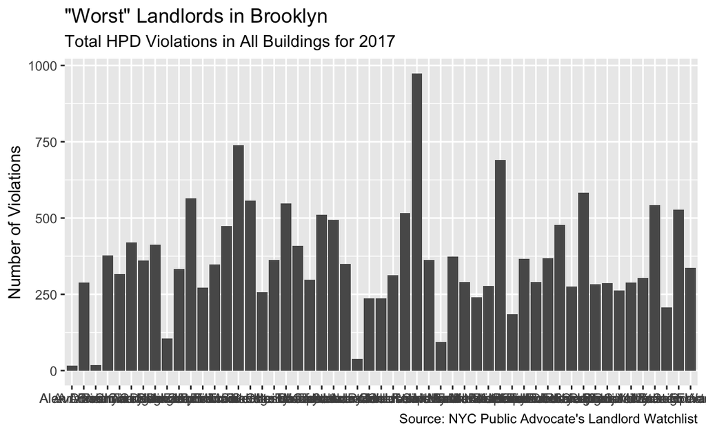

```r
ggplot(data = bk_landlords) +
  aes(x = landlord_name, y = total_viol) +
  geom_col() +
  labs(
    title = '"Worst" Landlords in Brooklyn',
    subtitle = "Total HPD Violations in All Buildings for 2017",
    x = NULL,
    y = "Number of Violations",
    caption = "Source: NYC Public Advocate's Landlord Watchlist"
  )
```

With only the defaults ggplot2 graphs tend to look pretty good, and are not too difficult to create. However, there are definitely some things we’ll want to improve with this graph. Luckily, there is a near-infinite amount of customization possible with ggplot2 to get the plot looking exactly the way you want.

To start, there are clearly too many landlords to display clearly in a graph like this, so we can use dplyr to`arrange` the data by violations and `filter` to keep only the top 10 landlords. The first landlord name doesn’t match the same format as the other, so let’s remove the `" Properties"` part using `str_remove` from the `stringr` package. It would also be nice if the landlords were sorted in order of the number of violations. To achieve this we can change the `landlord_name` column from a string to instead use R’s `factor` datatype, which allows us to specify an ordering to the values. Specifically, we’ll use the function `fct_reorder()` from the package `forcats` to make the column a factor and put the values in order based on the values of the `total_viol` column.

Now we can use this new dataframe with ggplot2 and make a few more changes to improve the graph further. One obvious problem with our initial graph is that the landlord names are completely illegible due to overlap. To solve this we can use the ggplot2 function `coord_flip()` to flip our bars sideways so we can read the labels more cleanly. Another smaller adjustment we can make it to format the violation count labels on our y-axis. To make changes to anything related to one of the *aes*thetic elements of a plot we can use one of the many `scale_*_*` functions. The first `*` is always one of the `aes` element types, and the second `*` indicates the type of data that is mapped to it. In our case we want to make a change to the y axis and we’ve mapped our count of violations to `y` so it a continuous scale, so the function we’ll want to use is `scale_y_continuous()`. Now within that function we’ll want to use the formatting function `comma` from the `scales` package on our axis labels. Lastly, we can use one of the `theme_*` functions to apply some alternative styling to the plot. These functions provide you some helpful preset styling, but you can make your own fine-tuned adjustments using `theme()`. This can get a bit overwhelming, but just to illustrate what’s possible, here we’ll remove the unnecessary lines on the plot, move the landlord name labels over a bit, and change the font of the caption.

If you have a package already installed, you can use a function from it without loading it with `library()` by using `package::function()`. Here we are doing this for `scales::comma` because we only use this single function from the package once.

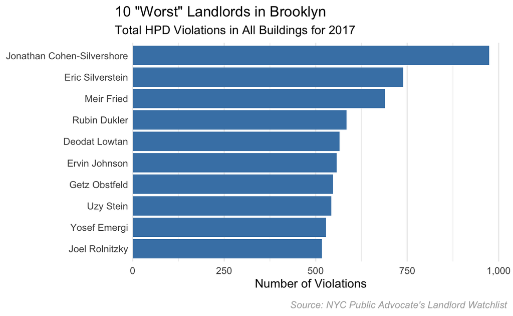

```r
landlord_bk_10_worst <- bk_landlords %>%
  arrange(desc(total_viol)) %>%
  filter(row_number() <= 10) %>%
  mutate(
    landlord_name = str_remove(landlord_name, " Properties"),
    landlord_name = fct_reorder(landlord_name, total_viol)
  )
ggplot(data = landlord_bk_10_worst) +
  aes(x = landlord_name, y = total_viol) +
  geom_col(fill = "steelblue") +
  coord_flip() +
  scale_y_continuous(labels = scales::comma) +
  theme_minimal() +
  theme(
    panel.grid.major.y = element_blank(),
    axis.text.y = element_text(margin = margin(r = -15)),
    plot.caption = element_text(face = "italic", color = "darkgrey", margin = margin(t = 10))
  ) +
  labs(
    title = '10 "Worst" Landlords in Brooklyn',
    subtitle = "Total HPD Violations in All Buildings for 2017",
    x = NULL,
    y = "Number of Violations",
    caption = "Source: NYC Public Advocate's Landlord Watchlist"
  )
```